# Hierarchical Clustering

John Mayberry

2025-03-26

## What is hierarchical clustering?

Hierarchical clustering is the second primary class of clustering algorithms and one which does not require the user to pre-specify a number of clusters. Instead, hierarchical clustering[^1] seeks to organize all samples into an ancestral-like tree called a dendrogram that shows which points are most closely related to each other. The algorithm proceeds as follows.

- At each step, calculate a matrix of pairwise “distances” between all current clusters
- Merge the two clusters which are “closest”.

Initially, all points are considered their own clusters so at stage one, we compute all pairwise distances between points and merge the two closest points. The choice of distance metric (called the dissimilarity measure) may vary from problem to problem, but is usually taken as the $\ell_2$/Euclidean distance.

Once we merge two points, we have to decide how to treat this cluster in future dissimilarity calculations. The choice we make is called the linkage criteria and there are three main options:

- Do we compute the mean distance from a point to the cluster? If so, we are using a mean-linkage criteria.
- Do we compute the minimum distance from a point to the cluster? If so, we are using single-linkage.
- Do we compute the maximum distance of the point to the cluster? If so, we are using complete-linkage.

To illustrate, suppose we have four points $x_1=(0,0), x_2=(1,0), x_3=(3,1), x_4=(6,1)$ and we are using Euclidean distance as our dissimilarity metric. At stage one, we compute all pairwise distances between points and find that $x_1,x_2$ are the closest points. We therefore merge them into a cluster $\{x_1,x_2\}$. At the next stage, we have to compute the dissimilarity between each other point and this cluster. This requires us to decide on the linkage. Here are the dissimilarities between $x_3$ and the $\{x_1,x_2\}$ cluster under the three most common choices

Mean-linkage: The mean of $x_1,x_2$ is $(1/2, 0)$ which has distance
$$\sqrt{(5/2)^2+1^2} \approx 2.69$$
from $x_3$.

Single-linkage: The closest point from $x_3$ in the cluster is $x_2$ so the dissimilarity between $x_3$ and the cluster is $\sqrt{5}\approx 2.24$.

Complete-linkage: The furthest point from $x_3$ in the cluster is $x_1$ so the dissimilarity is $\sqrt{10} \approx 3.16$.

These are shown in the figure below[^2]:

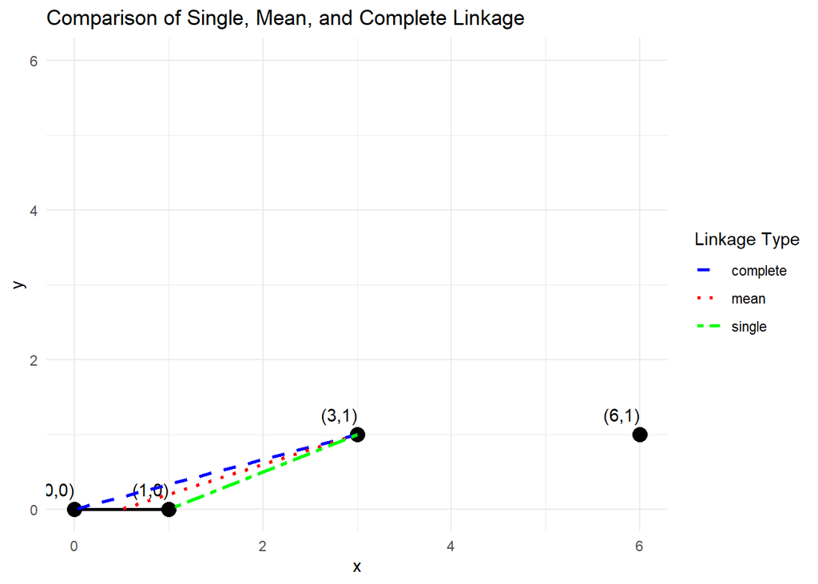

```r
# Define the four points
points_df <- data.frame(
  x = c(0, 1, 3, 6),
  y = c(0, 0, 1, 1),
  label = c("(0,0)", "(1,0)", "(3,1)", "(6,1)")
)

# Compute the mean linkage point
mean_x <- mean(c(0, 1))
mean_y <- mean(c(0, 0))

# Define the distances
linkages_df <- data.frame(
  x1 = c(3, 3, 3),
  y1 = c(1, 1, 1),
  x2 = c(0, mean_x, 1),
  y2 = c(0, mean_y, 0),
  type = c("complete", "mean", "single")
)

# Create the plot
ggplot(points_df, aes(x, y)) +
  geom_point(size = 4, color = "black") +
  geom_text(aes(label = label), vjust = -1, hjust = 1) +

  # Cluster bond
  geom_segment(aes(x = 0, y = 0, xend = 1, yend = 0), color = "black", size = 1) +

  # Linkage distances
  geom_segment(data = linkages_df, aes(x = x1, y = y1, xend = x2, yend = y2, linetype = type, color = type), size = 1) +

  scale_linetype_manual(values = c("dashed", "dotted", "twodash")) +  # Different dashed line styles
  scale_color_manual(values = c("blue", "red", "green")) +  # Different colors for linkage types
  labs(title = "Comparison of Single, Mean, and Complete Linkage",
       linetype = "Linkage Type",
       color = "Linkage Type") +
  theme_minimal()+
  ylim(c(0,6))
```

You can see why the choice of dissimilarity matters! $x_4$ is distance 3 from $x_3$ (and further from $x_1,x_2$ no matter which way you look at it). So under mean or single linkage, our next step would be to merge $x_3$ with $\{x_1,x_2\}$ but under complete, we would first merge $x_3$ with $x_4$.

## Computing a Hierarchical Cluster Object in R

Here is code to perform hierarchical clustering on our toy example above using all three types of linkage:

```r
toy_df=data.frame(x=c(0,1,3,6),y=c(0,0,1,1))
hc_complete=hclust(dist(toy_df),method="complete")
hc_single=hclust(dist(toy_df),method="single")
hc_avg=hclust(dist(toy_df),method="average")
```

A dendrogram[^3] is a tree-diagram that can be used to visualize the steps performed in hierarchical clustering and view similarities between points. You can obtain a dendrogram by plotting the output of a call to hclust

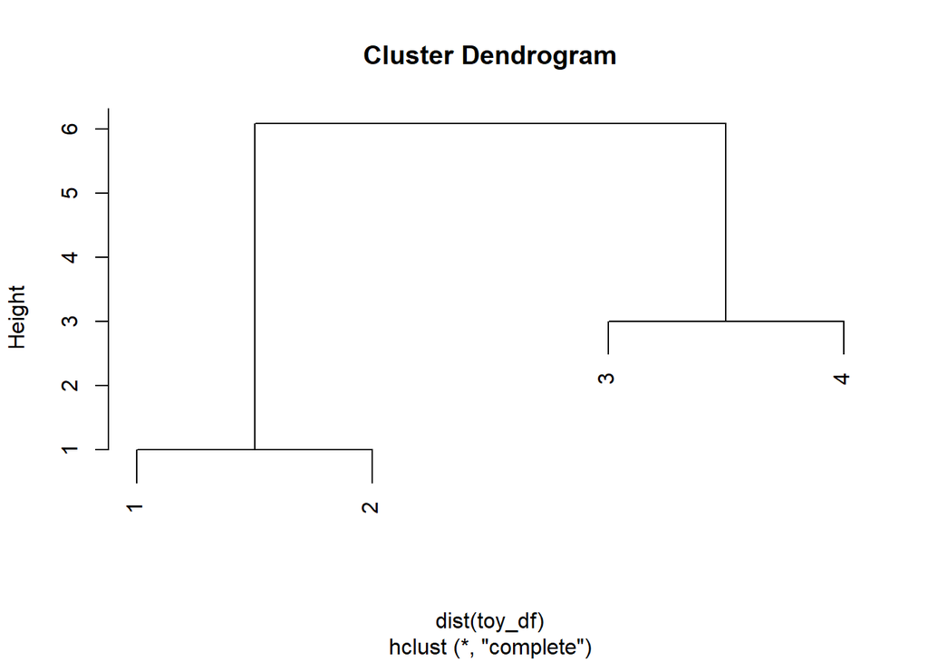

```r
plot(hc_complete)
```

This demonstrates the fact that under complete-linkage, 1 and 2 are merged first followed by 3 and 4. Note that the “Height” variable displays the distance at which clusters were merged. For example, 1 and 2 were merged first at a height of 1 because they are one unit apart whereas 3 and 4 were merged next at a Height of 3. Finally, the maximum distance between any pairs of points in the $\{x_1,x_2\}$ vs $\{x_3,x_4\}$ cluster is $\sqrt{37}\approx 6.08$ which is the height of the next merger.

In contrast, the single linkage exhibits a different merger pattern. We still merge 1 and 2 first, but 3 joins their family before meeting up with 4:

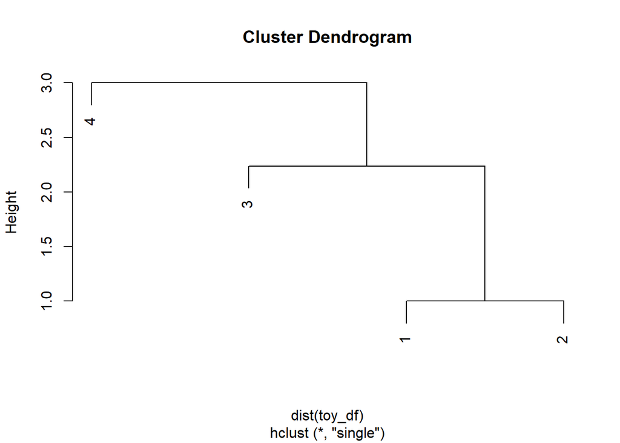

```r
plot(hc_single)
```

In this case, using average distance gives the same picture as single:

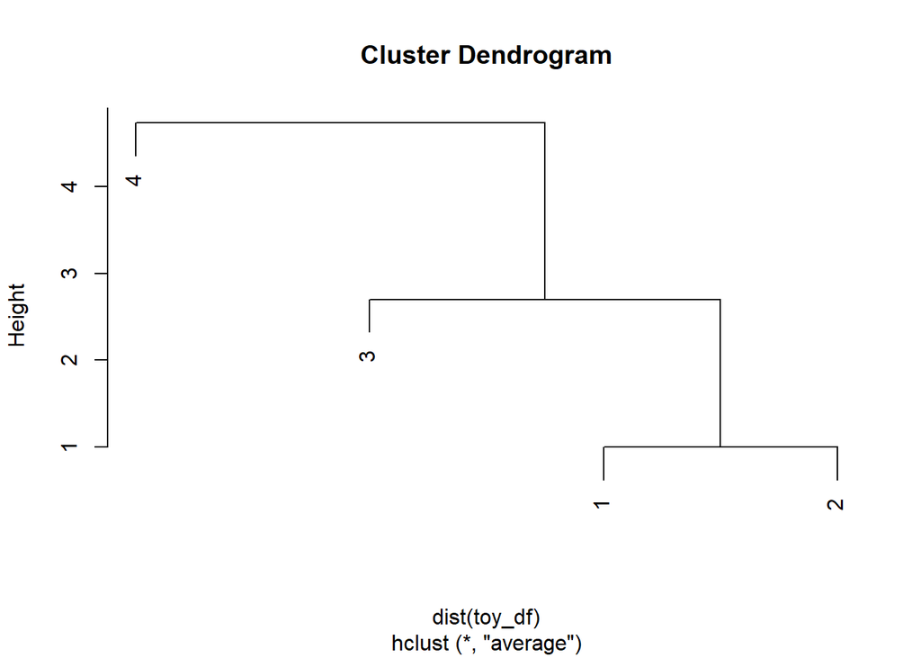

```r
plot(hc_avg)
```

## From dendrograms to clusters

To actually form clusters of objects out of a dendrogram, one must choose a cut height and then group all objects together whose branches merge below the cutpoint. For example, in the complete-linkage case, choosing a cut height of 2 would create three clusters, one containing $\{x_1,x_2\}$ with $x_3,x_4$ in their own clusters:

```r
cutree(hc_complete,h=2)
```

```
## [1] 1 1 2 3
```

Using a height of 3, however, would create two clusters with $\{x_3,x_4\}$ now together.

```r
cutree(hc_complete,h=3)
```

```
## [1] 1 1 2 2
```

Choosing a height above $\sqrt{37}$ will just create one supercluster

```r
cutree(hc_complete,h=sqrt(37))
```

```
## [1] 1 1 1 1
```

You can visualize all this as follows by plotting the cut heights alongside the tree

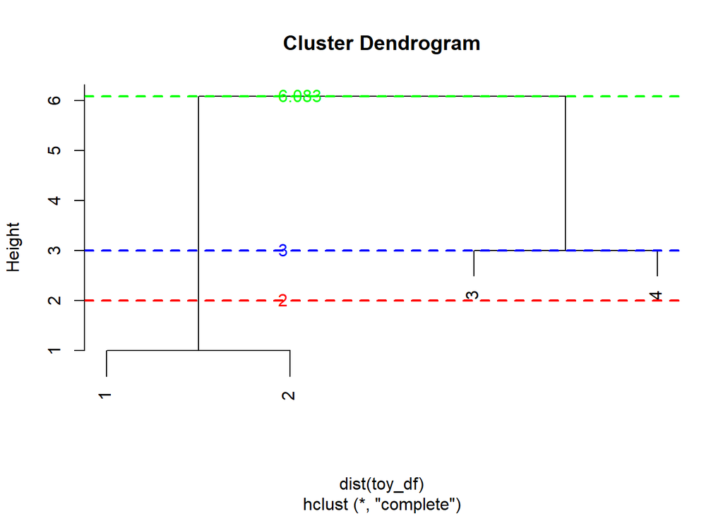

```r
plot(hc_complete)  # Plot the dendrogram

# Heights for the cut lines
heights <- c(2, 3, sqrt(37))

# Add horizontal lines
abline(h = heights, col = c("red", "blue", "green"), lty = 2, lwd = 2)

# Add labels for the heights
text(x = par("usr")[1] + 1, y = heights,
     labels = round(heights, 3), col = c("red", "blue", "green"), pos = 4)
```

We’ll leave it to you to play around with the single case!

## Election Data….Again…

We’ve had so much fun with this dataset. I am dying to see what a state dendrogram looks like! Note that we definitely should scale each column before we compute distances.

```r
election_hc=hclust(dist(scale(election2016[,2:9])),method="complete")
```

Let’s see what this crazy-ass thing will look like:

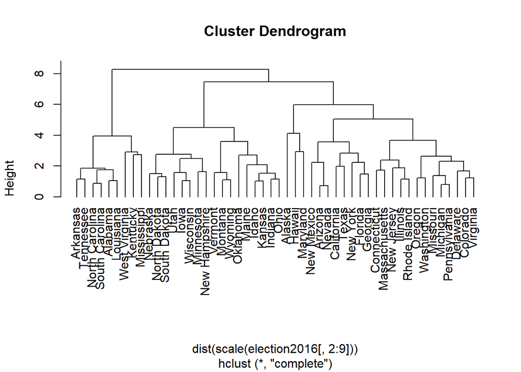

```r
plot(election_hc,hang=-1,labels=election2016$state)
```

We can get different clustering depending on the cut height. Using h=6 gives us three clusters of unequal size

```r
cluster1=cutree(election_hc,h=6)
table(cluster1)
```

```
## cluster1
##  1  2  3
##  9 24 17
```

Using a lower height of 5 gives five groups

```r
cluster2=cutree(election_hc,h=5)
table(cluster2)
```

```
## cluster2
##  1  2  3  4  5
##  9  3  8 13 17
```

Deciding upon a good cut point sort of just shifts the problem of setting the number of clusters ahead of time in K-means to a later stage in the problem (although the advantage is that you only have to do the grouping work once and can more easily experiment around with different cuts at this point).

Now, let’s see how the states are clustered. Here is the three cluster figure with 2D snapshot of Median Income and Non-citizen from last time.

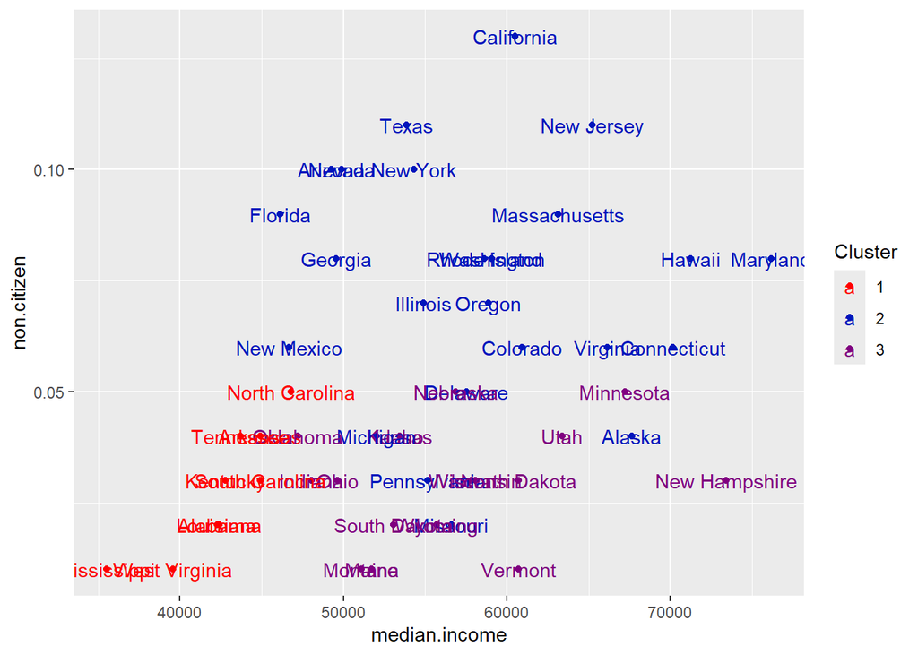

```r
election2016$ClusterHC3=cluster1
ggplot(election2016,
       aes(x=median.income,y=non.citizen,label=state,color=as.factor(ClusterHC3)))+
  geom_point()+
  geom_text()+
  scale_color_manual(name="Cluster",values=c("#FF0000","#0015BC", "#800080"))
```

One could also look at mean characteristic of a variable by cluster using the group_by command. We’ll demonstrate for the three cluster case and four of our variables:

```r
election2016 %>% group_by(ClusterHC3) %>%
  summarize(median.income=mean(median.income),
            high.school=mean(high.school),
            income.ineq=mean(income.ineq),
            metro=mean(metro))
```

```
## # A tibble: 3 × 5
##   ClusterHC3 median.income high.school income.ineq metro
##        <int>         <dbl>       <dbl>       <dbl> <dbl>
## 1          1        42544.       0.825       0.465 0.674
## 2          2        58486.       0.865       0.459 0.878
## 3          3        56562.       0.898       0.436 0.595
```

## From unsupervised back to supervised: Predicting outcomes based on clusters

Of course, the overall goal of our election2016 data was to predict presidential voting based on the eight demographic features of states. Suppose we wish to compare the three different methods for predicting election outcomes:

- PCA
- K-means Clustering
- Hierarchical Clustering

In each case, we’ll have to use our unsupervised methods to cut the data into two clusters and compare the results. We should probably do training/testing sets or some kind of cross-validation, but feeling a bit tired of that so let’s just use the overall error rate today. For self-containment, here are the relevant commands from the last three notes

```r
election_2means=kmeans(election2016[,2:9],centers=2,nstart=100)
election_hc=hclust(dist(scale(election2016[,2:9])),method="complete")
election_pc=princomp(election2016[,2:9],cor=TRUE)
```

The kmeans result is ready to go. When can create a “confusion” matrix for the clusters compared to election outcomes

```r
table(election_2means$cluster,election2016$outcome)
```

```
##
##     Blue Red
##   1   15   7
##   2    5  23
```

```r
12/50
```

```
## [1] 0.24
```

Now, for the hierarchical clustering, we need to choose a cut so that we end up with k-groups. To do that, we use cutree, but supply a “k” instead of a cut-height:

```r
outcome_hc=cutree(election_hc,k=2)
table(outcome_hc,election2016$outcome)
```

```
##
## outcome_hc Blue Red
##          1    0   9
##          2   20  21
```

Hmm, that didn’t work too good. Both groups have more red than blue states (although cluster one is all red and 2 is close to 50-50). So I guess hierarchical in this case would say “always guess red”, i.e. we’re back at the null model. (In case you’re wondering, I tried average and single linkage but they are even worse). The issue is that the second cluster is too big. We could try three clusters like we did in the last notes

```r
outcome_hc=cutree(election_hc,k=3)
table(outcome_hc,election2016$outcome)
```

```
##
## outcome_hc Blue Red
##          1    0   9
##          2   16   8
##          3    4  13
```

That’s a little more interesting. It look like predicting blue for cluster 2 and predicting red for clusters 1 and 3 does alright, but the error rate would again be 12/50 though. .

Finally, we have PCA, the most complicated. Here is the old plot of the first two components, colored by outcome and labeled with Comp.2 value.

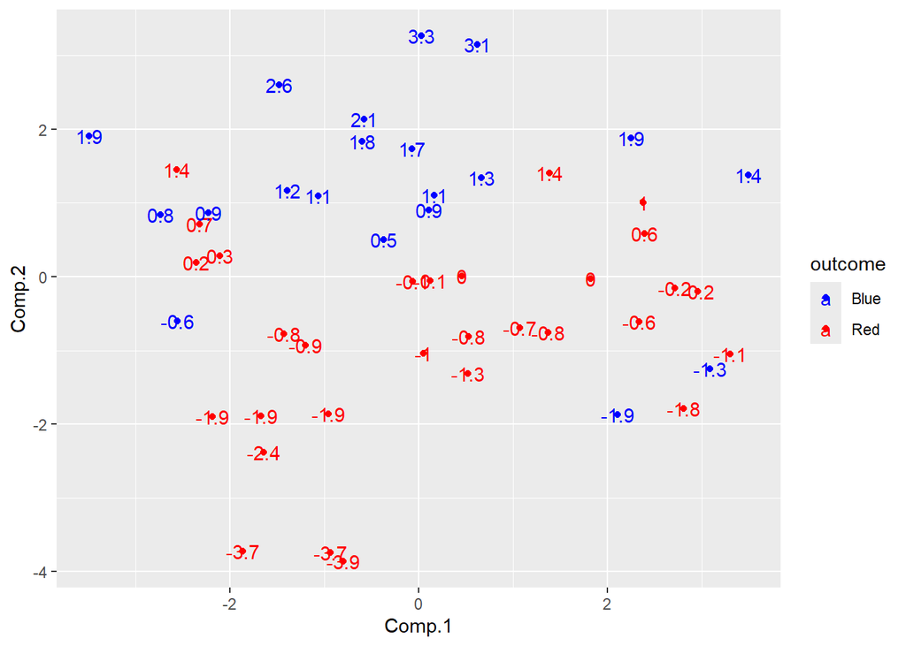

```r
electionPC=cbind(election2016,election_pc$scores[,1:2])
ggplot(electionPC,aes(x=Comp.1,y=Comp.2,color=outcome))+geom_point()+geom_text(aes(label=round(Comp.2,1)))+scale_color_manual(values=c("blue","red"))
```

It looks like splitting by Comp.2 will do well, perhaps “guess blue if Comp.2 >=0.5” based on what we see[^4]. Let’s check the confusion matrix

```r
table(election2016$outcome,electionPC$Comp.2>=0.5)
```

```
##
##        FALSE TRUE
##   Blue     3   17
##   Red     25    5
```

Yeah, not bad. The error rate would be 8/50 or about 0.16. To compare with logistic regression (full model):

```r
formula=as.formula(paste('outcome==\"Red\" ~',                      paste(names(election2016)[2:9],collapse="+")))
outcome_glm=glm(formula,data=election2016,family="binomial")
table(election2016$outcome,predict(outcome_glm,type="response")>=0.5)
```

```
##
##        FALSE TRUE
##   Blue    16    4
##   Red      1   29
```

The error rate here is only 10% so still better. Man, unsupervised methods can just fuck off when it comes to prediction.

I am kidding of course. We are trying to force them to give us a certain splitting, one which is good for predicting the 2016 election, but there is no guarantee that they will comply. The lesson here is that the eight features we are feeding into our models do not just “naturally” split states along election lines, at least not completely. There must be some other variables we are not accounting for.

## Next up…

In Module 6, we’ll explore classification and regression tree (CART) models, a powerful tool for visualizing predictive models, but one that can suffer from high variance. We’ll also discuss ensemble methods like bagging and random forests, which help reduce variance and improve predictive accuracy.

[^1]: which we should also start calling the Chiana Method to make up for her first grade statistical shaming.
[^2]: clearly made with chatGPT because of the excessive comments.
[^3]: literally Greek for tree-diagram.
[^4]: For a better way of splitting points in planes, see the book chapter on Support Vector Machines, another cool topic